# Analyze Glioblastoma RNA-seq Data

Romario Romain & Erin Osborne Nishimura

4/5/2021

# Analysis: DESeq2 analysis

The purpose of this analysis is to analyze Pollak et al., 2017 paper that presented RNA-seq data on neuronal cells versus Glioblastoma cancer cells.

## Step 1: Install required libraries if not already present; Load libraries:

Install the following if not already installed:

- DESeq2
- RColorBrewer
- pheatmap
- ggplot2
- BiocManager
- GenomicFeatures
- ensembldb
- biomaRt
- dplyr
- tibble
- tidyverse
- gridExtra

Load required packages.

```r
# Do this every time.
# Load packages:
library(DESeq2)
library(RColorBrewer)
library(pheatmap)
library(ggplot2)
library(BiocManager)
library(GenomicFeatures)
library(ensembldb)
library(biomaRt)
library(dplyr)
library(tibble)
library(tidyverse)
library(gridExtra)
```

Set date:

```
## [1] "210405"
```

## Step 2: Import the datasets

Import the counts dataset:

```r
# If necessary:

# import the counts data - aligned to hg38
countsData <- read.table(file = "../01_input/counts_210403.txt", header = TRUE, row.names = 1, skip = 2)
```

Import the metadata file:

```r
# Read in the metadata
metadata <- read.table(file = "../01_input/metadata_pollak_210402.txt", header = FALSE) # import the data
colnames(metadata) <- c("fasta1", "names", "celltype", "rep","cellOrigin")
metadata
```

```
##                      fasta1      names celltype rep   cellOrigin
## 1   Sample_0131-02-11.fastq   01_131_1      131   1 glioblastoma
## 2   Sample_0131-02-17.fastq   02_131_2      131   2 glioblastoma
## 3   Sample_0131-02-22.fastq   03_131_3      131   3 glioblastoma
## 4   Sample_0827-02-11.fastq   04_827_1      827   1 glioblastoma
## 5   Sample_0827-02-17.fastq   05_827_2      827   2 glioblastoma
## 6   Sample_0827-02-22.fastq   06_827_3      827   3 glioblastoma
## 7     Sample_1502_No1.fastq  07_1502_1     1502   1 glioblastoma
## 8     Sample_1502_No2.fastq  08_1502_2     1502   2 glioblastoma
## 9     Sample_1502_No3.fastq  09_1502_3     1502   3 glioblastoma
## 10 Sample_CB660-02-11.fastq 10_CB660_1    CB660   1     neuronal
## 11 Sample_CB660-02-17.fastq 11_CB660_2    CB660   2     neuronal
## 12 Sample_CB660-02-22.fastq 12_CB660_3    CB660   3     neuronal
## 13  Sample_G166-02-11.fastq  13_G166_1     G166   1 glioblastoma
## 14  Sample_G166-02-17.fastq  14_G166_2     G166   2 glioblastoma
## 15  Sample_G166-02-22.fastq  15_G166_3     G166   3 glioblastoma
## 16  Sample_G179-02-11.fastq  16_G179_4     G179   1 glioblastoma
## 17  Sample_G179-02-17.fastq  17_G179_5     G179   2 glioblastoma
## 18  Sample_G179-02-22.fastq  18_G179_6     G179   3 glioblastoma
```

## Step 3: Munge the data

Determine samples to analyze using the metadatafile

Append the metadata files to the countsData

Prepare the counts table:

One thing we need to do is explicitly check that the rownames of coldata exactly match the colnames of cts.

Do they match?

```r
#Check that the names match  --> Should be TRUE
all(rownames(coldata) == colnames(cts))
```

```
## [1] TRUE
```

## Step 4: Perform DESeq2 analysis

Run the DESeq2 analysis on the dataset

Filter for present genes

Only keep genes that have 10 or greater reads associated with them.

```r
# Exclude genes with fewer than 10 reads
keep <- rowSums(counts(dds)) >=10
dds <- dds[keep,]

# How many genes did we have before?
dim(cts)[1]
```

```
## [1] 20003
```

```r
# How many genes do we have now?
dim(dds)[1]
```

```
## [1] 16581
```

Run the DESeq2 analysis

```r
# PERFORM DESEQ2 analysis:
####### This is where the magic happens! ###########
# This will transform dds into a specialized object with many more fields filled in.
dds<- DESeq(dds)
# Organize the categories based on what makes sense:
dds$names<- factor(dds$names)
```

Exploratory data analysis

```r
#class(dds)
#str(dds)
#head(dds)
resultsNames(dds)
```

```
## [1] "Intercept"              "celltype_827_vs_CB660"  "celltype_1502_vs_CB660"
## [4] "celltype_131_vs_CB660"  "celltype_G166_vs_CB660" "celltype_G179_vs_CB660"
```

```r
dim(dds)
```

```
## [1] 16581    18
```

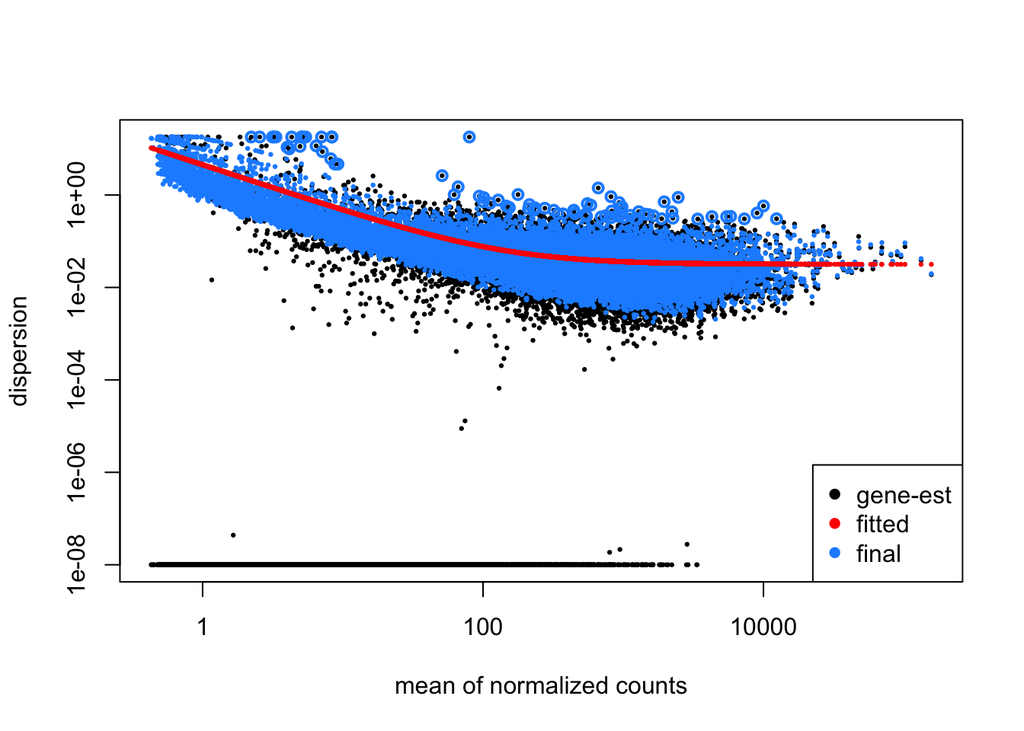

```r
plotDispEsts(dds)
```

What was the normalization scaling that was applied?

```
##   01_131_1   02_131_2   03_131_3   04_827_1   05_827_2   06_827_3  07_1502_1
##  0.8792566  0.9120411  0.6981746  0.9995185  1.0211272  1.1242376  1.2070697
##  08_1502_2  09_1502_3 10_CB660_1 11_CB660_2 12_CB660_3  13_G166_1  14_G166_2
##  1.3692896  1.3251308  0.8460441  0.7965677  0.8388745  1.0508563  1.0398165
##  15_G166_3  16_G179_4  17_G179_5  18_G179_6
##  1.1184975  1.0684842  1.0703946  1.1519292
```

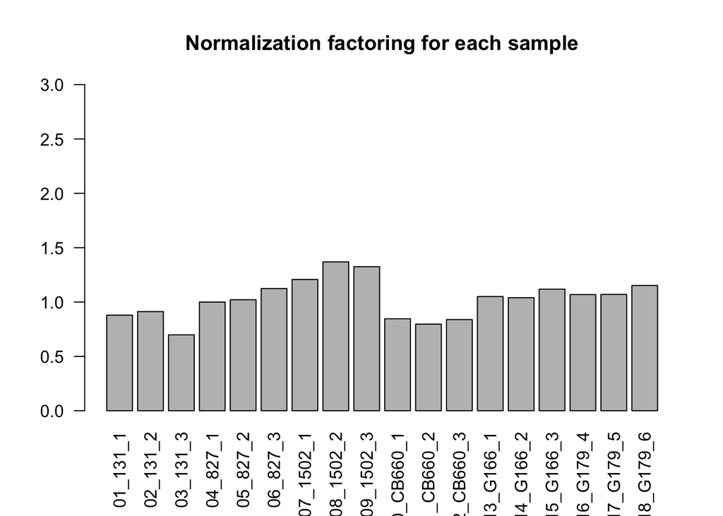

Excellent! We’re seeing even representation across all samples.

## Step 5: Append Ensemble identifiers to our dataset

First, import the gene names, either from EnsemblDB or from an input file:

```r
# Second time on...import the gene_names from the input folder
gene_names <-read.table(file = "../01_input/210116_ensembleLookuptable.txt", header = TRUE)
```

Write a script to append the gene names to the identifiers in a data.frame:

## Step 6: Export data tables.

Some data tables to export and include in the study as supplemental data tables.

```r
# ###### RAW COUNTS ##########
#
# # create raw counts tables for supplemental figures
raw_counts <- counts(dds, normalized = FALSE)
merged_raw_counts <- add_external_name(raw_counts)
#
# ###### NORMALIZED COUNTS ##########
#
# # create normalized counts tables for supplemental figures
 norm_counts <- counts(dds, normalized = TRUE)
 merged_norm_counts <- add_external_name(norm_counts)
#
# ###### R-STABILIZED LOG COUNTS ##########
# rdl_all <- as.data.frame(assay(rlog(dds, blind=FALSE)))
# merged_rdl <- add_external_name(rdl_all)
#
# ####### save raw counts file for supplemental datatable ######
# filename = paste("../03_output/", today, "_raw_counts.txt", sep = "")
# write.table(merged_raw_counts, file = filename, sep = "\t", quote = FALSE, row.names = FALSE)
#
# ####### save normalized raw counts file for supplemental datatable ######
# filename = paste("../03_output/", today, "_norm_counts.txt", sep = "")
# write.table(merged_norm_counts, file = filename, sep = "\t", quote = FALSE, row.names = FALSE)
#
# ####### save normalized raw counts file for supplemental datatable ######
# filename = paste("../03_output/", today, "_RStabilized_log_counts.txt", sep = "")
# write.table(merged_rdl, file = filename, sep = "\t", quote = FALSE, row.names = FALSE)
```

## Step 7: Plot a distance matrix

```
##                 01_131_1 02_131_2 03_131_3 04_827_1 05_827_2 06_827_3 07_1502_1
## ENSG00000284733        0        0        0        0        0        0         0
## ENSG00000284662        0        0        0        0        0        0         0
## ENSG00000187634        4       35       57        0        9        1         2
## ENSG00000188976     2286     2043     1904     2199     1920     2296      2219
## ENSG00000187961      265      331      389      390      371      347       373
## ENSG00000187583       93       67       25        1        1        1        40
##                 08_1502_2 09_1502_3 10_CB660_1 11_CB660_2 12_CB660_3 13_G166_1
## ENSG00000284733         0         0          0          0          0         0
## ENSG00000284662         0         0          0          0          0         0
## ENSG00000187634        11         8         15         17         31         0
## ENSG00000188976      2540      2455        797        726        918      2045
## ENSG00000187961       388       373        191        203        229       214
## ENSG00000187583        51        62         11          2          5        70
##                 14_G166_2 15_G166_3 16_G179_4 17_G179_5 18_G179_6
## ENSG00000284733         0         0         0         0         0
## ENSG00000284662         0         0         0         0         0
## ENSG00000187634         2        12        13        30       138
## ENSG00000188976      1664      2403      1595      1375      1360
## ENSG00000187961       193       238       162       169       270
## ENSG00000187583        72        88        79        61        76
```

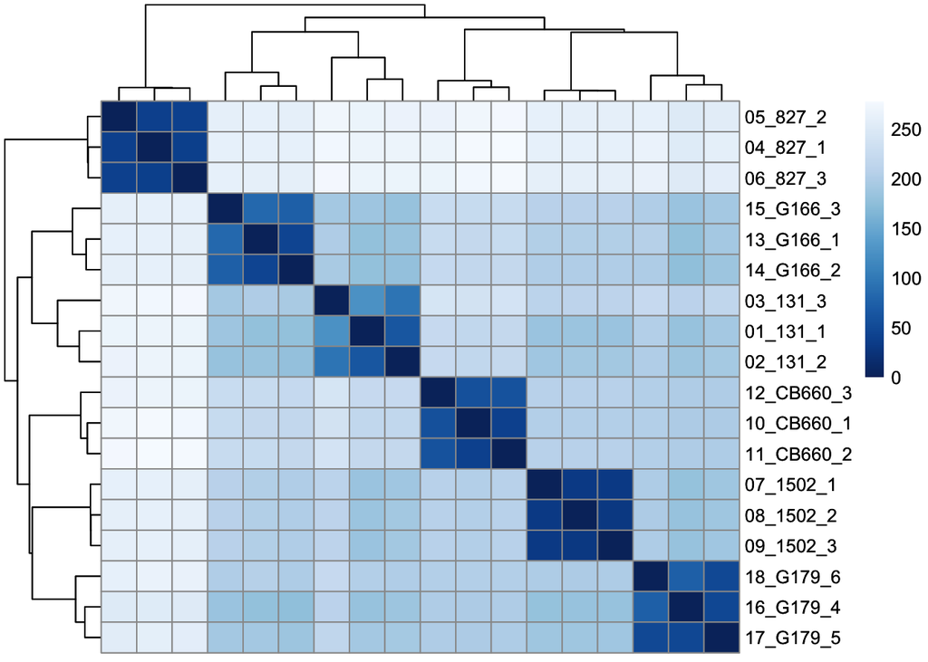

Excellent separation between all conditions.

## Step 8: Generate a PCA plot:

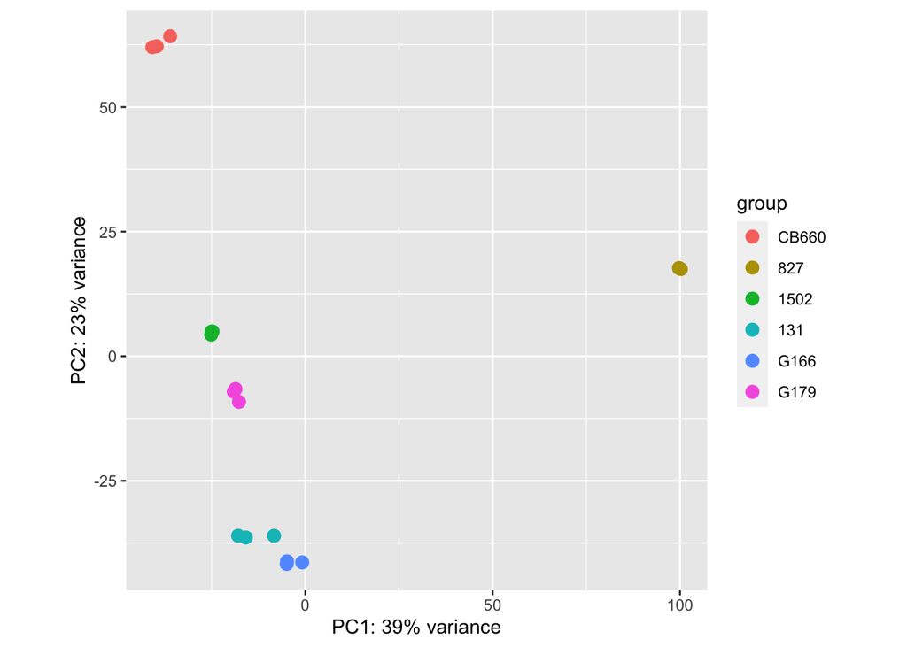

## Step 9: Plot some key, individual genes

Write the function plot_ensembl and gather genes:

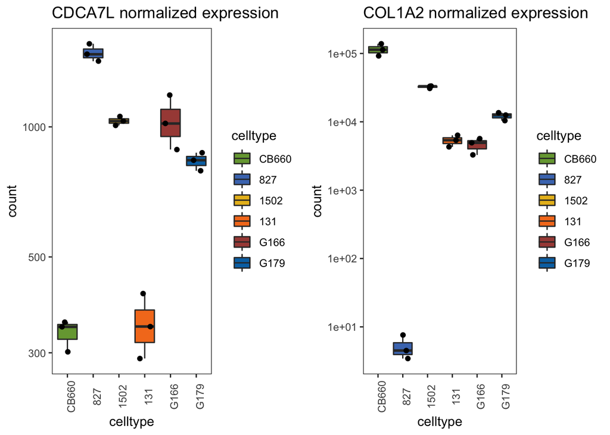

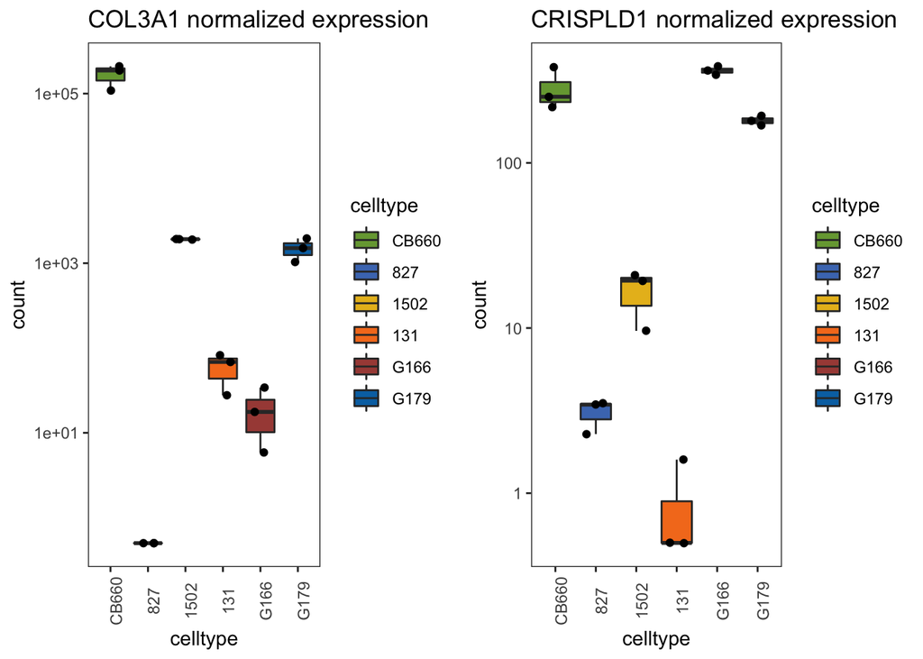

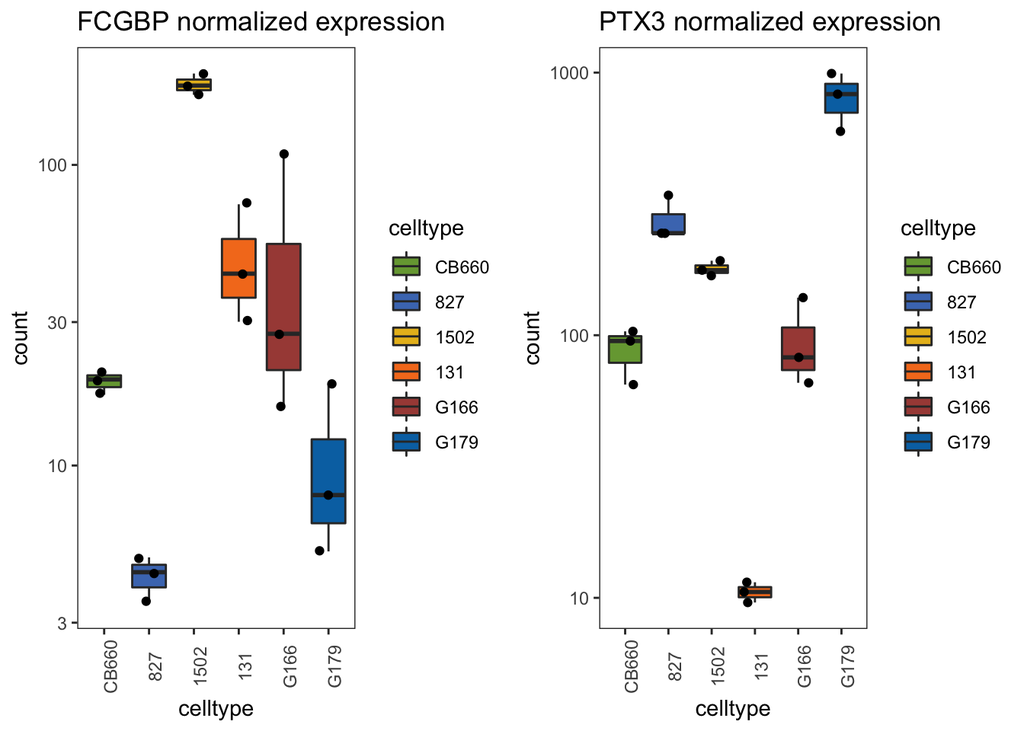

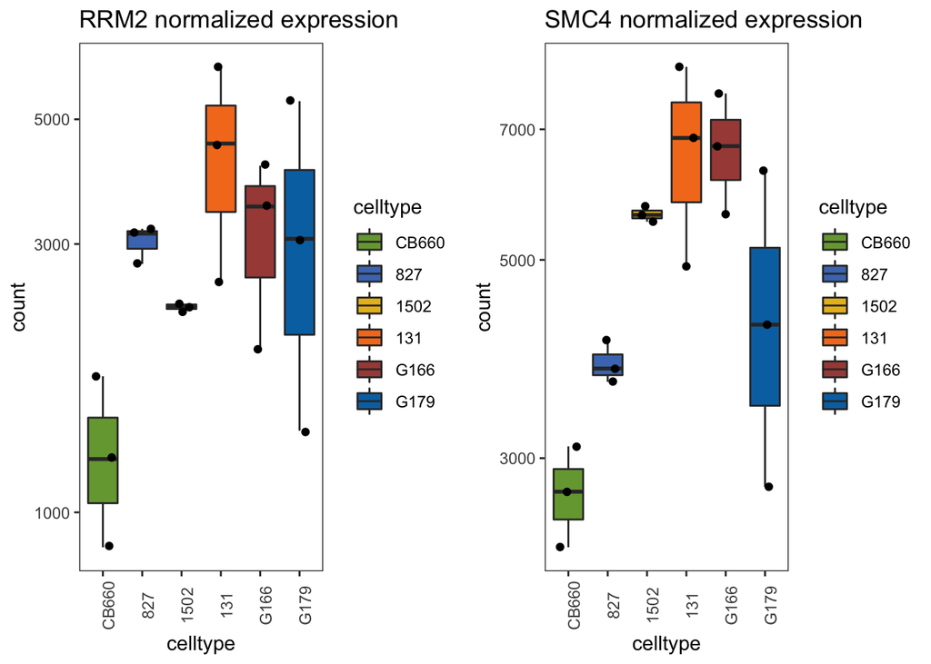

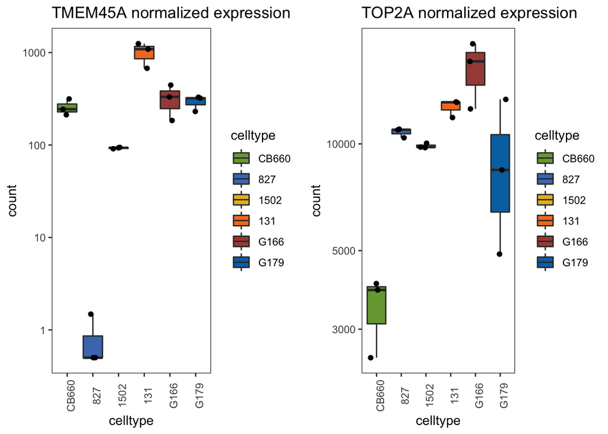

Here are some general cancer-related RAS/MEK/AKT genes:

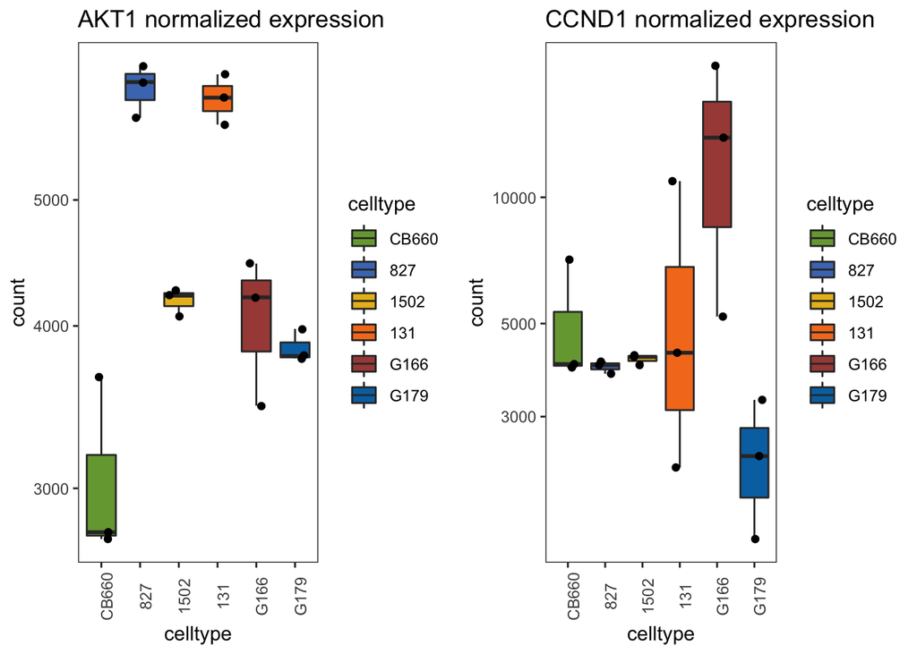

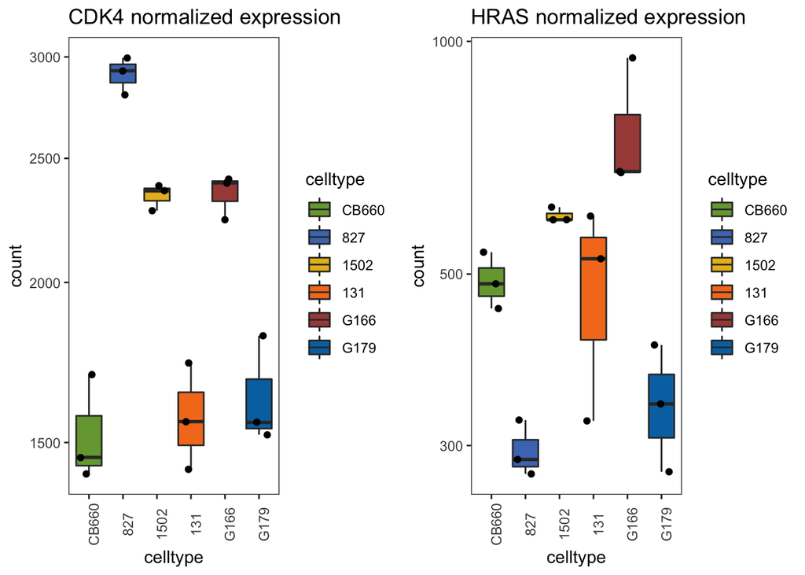

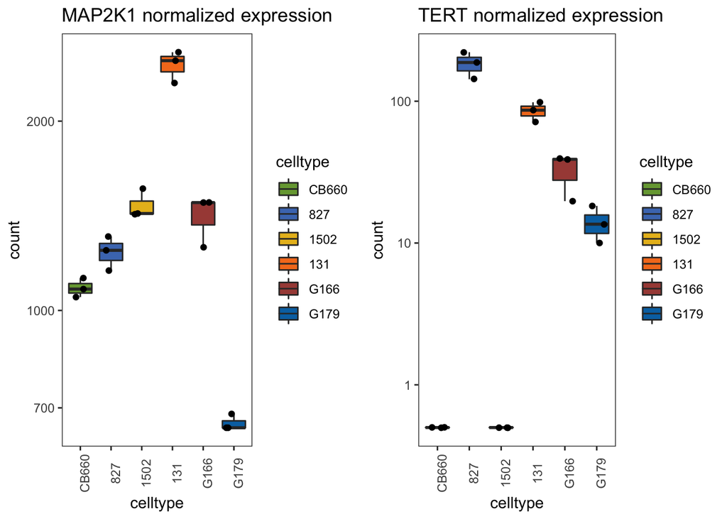

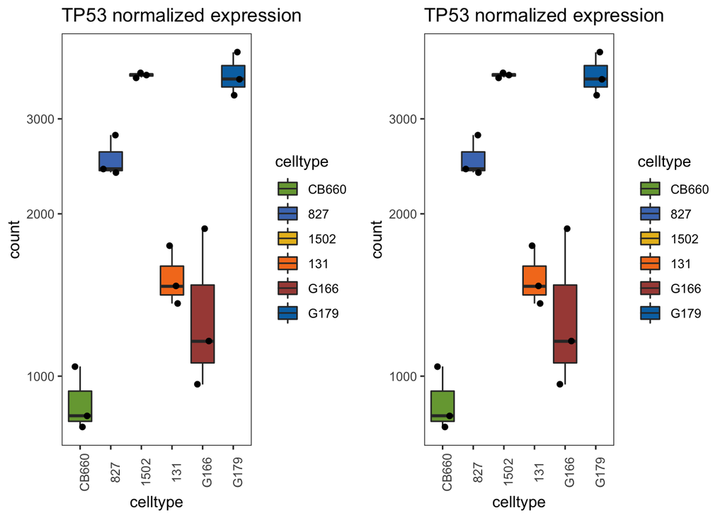

## Step 10: Identify pairwise differentially expressed genes

Write function calc_pairwise_results to calculate pairwise results tables

Calculate all neuronal v. GBM comparisons

```r
# Write key functions to calculate Threshold values

calc_pairwise_results <- function(cond1, cond2, lfc){
  res <- results(dds, contrast=c("celltype", cond1, cond2),
                 alpha = 0.01, lfcThreshold = lfc, cooksCutoff = FALSE)
  res <- res[order(res$padj, na.last = TRUE),]
  return(res)
}

# Perform pairwise comparisons against the neuronal type: CB660
# lfc = 1; default padj = 0.01
#CB660 827 1502 131 G166 G179
res_CB660_vs_827 <- calc_pairwise_results("827","CB660", 2)
res_CB660_vs_1502 <- calc_pairwise_results("1502", "CB660", 2)
res_CB660_vs_131 <- calc_pairwise_results("131", "CB660", 2)
res_CB660_vs_G166 <- calc_pairwise_results("G166", "CB660", 2)
res_CB660_vs_G179 <- calc_pairwise_results("G179", "CB660", 2)
```

Report the summaries of the res-plots:

```r
# Report summaries
summary(res_CB660_vs_827)
```

```
##
## out of 16581 with nonzero total read count
## adjusted p-value < 0.01
## LFC > 2.00 (up)    : 565, 3.4%
## LFC < -2.00 (down) : 1321, 8%
## outliers [1]       : 0, 0%
## low counts [2]     : 643, 3.9%
## (mean count < 1)
## [1] see 'cooksCutoff' argument of ?results
## [2] see 'independentFiltering' argument of ?results
```

```r
summary(res_CB660_vs_1502)
```

```
##
## out of 16581 with nonzero total read count
## adjusted p-value < 0.01
## LFC > 2.00 (up)    : 537, 3.2%
## LFC < -2.00 (down) : 475, 2.9%
## outliers [1]       : 0, 0%
## low counts [2]     : 0, 0%
## (mean count < 0)
## [1] see 'cooksCutoff' argument of ?results
## [2] see 'independentFiltering' argument of ?results
```

```r
summary(res_CB660_vs_131)
```

```
##
## out of 16581 with nonzero total read count
## adjusted p-value < 0.01
## LFC > 2.00 (up)    : 470, 2.8%
## LFC < -2.00 (down) : 729, 4.4%
## outliers [1]       : 0, 0%
## low counts [2]     : 0, 0%
## (mean count < 0)
## [1] see 'cooksCutoff' argument of ?results
## [2] see 'independentFiltering' argument of ?results
```

```r
summary(res_CB660_vs_G166)
```

```
##
## out of 16581 with nonzero total read count
## adjusted p-value < 0.01
## LFC > 2.00 (up)    : 479, 2.9%
## LFC < -2.00 (down) : 736, 4.4%
## outliers [1]       : 0, 0%
## low counts [2]     : 0, 0%
## (mean count < 0)
## [1] see 'cooksCutoff' argument of ?results
## [2] see 'independentFiltering' argument of ?results
```

```r
summary(res_CB660_vs_G179)
```

```
##
## out of 16581 with nonzero total read count
## adjusted p-value < 0.01
## LFC > 2.00 (up)    : 586, 3.5%
## LFC < -2.00 (down) : 430, 2.6%
## outliers [1]       : 0, 0%
## low counts [2]     : 0, 0%
## (mean count < 0)
## [1] see 'cooksCutoff' argument of ?results
## [2] see 'independentFiltering' argument of ?results
```

## Step 11: Plot the MA-Plots

MA plots of pairwise comparisons

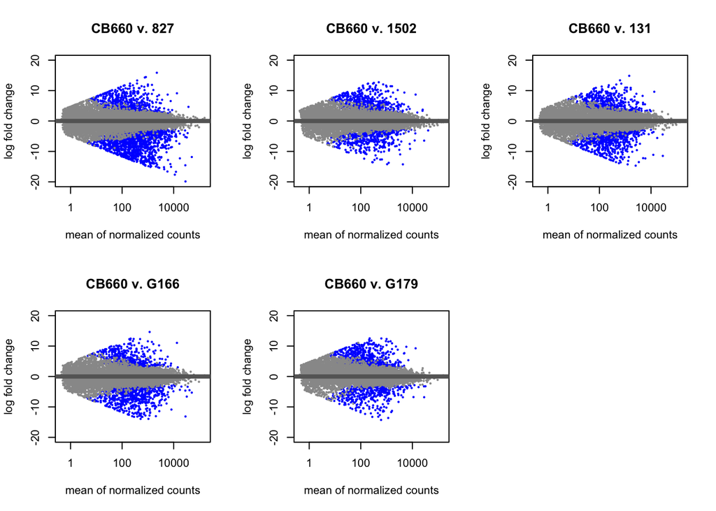

Save MA plots to .pdf’s:

```r
# Printout MA-Plots
filename = paste("../03_output/", today, "_MAplots.pdf", sep = "")
pdf(file = filename, height = 6, width = 6)
  par(mfrow=c(2,3))
  plotMA(res_CB660_vs_827, main="CB660 v. 827", ylim=c(-20,20))
  plotMA(res_CB660_vs_1502, main="CB660 v. 1502", ylim=c(-20,20))
  plotMA(res_CB660_vs_131, main="CB660 v. 131", ylim=c(-20,20))
  plotMA(res_CB660_vs_G166, main="CB660 v. G166", ylim=c(-20,20))
  plotMA(res_CB660_vs_G179, main="CB660 v. G179", ylim=c(-20,20))
  dev.off()
```

## Step 12: Generate and export gene lists

```r
# find the up_in_X and down_in_X genesets:
# lfc = 0.2; alpha = 0.1

# Up in
Up_in_827 <- subset(res_CB660_vs_827, padj < 0.01 & log2FoldChange > 2)
Up_in_1502 <- subset(res_CB660_vs_1502, padj < 0.01 & log2FoldChange > 2)
Up_in_131 <- subset(res_CB660_vs_131, padj < 0.01 & log2FoldChange > 2)
Up_in_G166 <- subset(res_CB660_vs_G166, padj < 0.01 & log2FoldChange > 2)
Up_in_G179 <- subset(res_CB660_vs_G179, padj < 0.01 & log2FoldChange > 2)

# Down in
Down_in_827 <- subset(res_CB660_vs_827, padj < 0.01 & log2FoldChange < -2)
Down_in_1502 <- subset(res_CB660_vs_1502, padj < 0.01 & log2FoldChange < -2)
Down_in_131 <- subset(res_CB660_vs_131, padj < 0.01 & log2FoldChange < -2)
Down_in_G166 <- subset(res_CB660_vs_G166, padj < 0.01 & log2FoldChange < -2)
Down_in_G179 <- subset(res_CB660_vs_G179, padj < 0.01 & log2FoldChange < -2)

# Add external names
merged_up_in_827 <- add_external_name(Up_in_827)
merged_up_in_1502 <- add_external_name(Up_in_1502)
merged_up_in_131 <- add_external_name(Up_in_131)
merged_up_in_G166 <- add_external_name(Up_in_G166)
merged_up_in_G179 <- add_external_name(Up_in_G179)

merged_down_in_827 <- add_external_name(Down_in_827)
merged_down_in_1502 <- add_external_name(Down_in_1502)
merged_down_in_131 <- add_external_name(Down_in_131)
merged_down_in_G166 <- add_external_name(Down_in_G166)
merged_down_in_G179 <- add_external_name(Down_in_G179)

# Write files - up lists:
filename1 = paste("../03_output/", today, "_1_upIn827.txt", sep = "")
write.table(file = filename1, merged_up_in_827, sep = "\t", quote = FALSE, row.names = FALSE)

filename1 = paste("../03_output/", today, "_2_upIn1502.txt", sep = "")
write.table(file = filename1, merged_up_in_1502, sep = "\t", quote = FALSE, row.names = FALSE)

filename1 = paste("../03_output/", today, "_3_upIn131.txt", sep = "")
write.table(file = filename1, merged_up_in_131, sep = "\t", quote = FALSE, row.names = FALSE)

filename1 = paste("../03_output/", today, "_4_upInG166.txt", sep = "")
write.table(file = filename1, merged_up_in_G166, sep = "\t", quote = FALSE, row.names = FALSE)

filename1 = paste("../03_output/", today, "_5_upInG179.txt", sep = "")
write.table(file = filename1, merged_up_in_G179, sep = "\t", quote = FALSE, row.names = FALSE)


# Write files - down lists:
filename1 = paste("../03_output/", today, "_6_upIn827.txt", sep = "")
write.table(file = filename1, merged_down_in_827, sep = "\t", quote = FALSE, row.names = FALSE)

filename1 = paste("../03_output/", today, "_7_downIn1502.txt", sep = "")
write.table(file = filename1, merged_down_in_1502, sep = "\t", quote = FALSE, row.names = FALSE)

filename1 = paste("../03_output/", today, "_8_downIn131.txt", sep = "")
write.table(file = filename1, merged_down_in_131, sep = "\t", quote = FALSE, row.names = FALSE)

filename1 = paste("../03_output/", today, "_9_downInG166.txt", sep = "")
write.table(file = filename1, merged_down_in_G166, sep = "\t", quote = FALSE, row.names = FALSE)

filename1 = paste("../03_output/", today, "_10_downInG179.txt", sep = "")
write.table(file = filename1, merged_down_in_G179, sep = "\t", quote = FALSE, row.names = FALSE)
```

## Step 14: Export the results tables and the DESeq object as files

```r
# Write to .txt files
filename = paste("../03_output/", today, "_results_CB660_vs_827.txt", sep = "")
write.table(df_res_CB660_vs_827, file = filename, sep = "\t", quote = FALSE, row.names = FALSE)

filename = paste("../03_output/", today, "_resultsTable_CB660_vs_1502.txt", sep = "")
write.table(df_res_CB660_vs_1502, file = filename, sep = "\t", quote = FALSE, row.names = FALSE)

filename = paste("../03_output/", today, "_resultsTable_CB660_vs_131.txt", sep = "")
write.table(df_res_CB660_vs_131, file = filename, sep = "\t", quote = FALSE, row.names = FALSE)

filename = paste("../03_output/", today, "_resultsTable_CB660_vs_G166.txt", sep = "")
write.table(df_res_CB660_vs_G166, file = filename, sep = "\t", quote = FALSE, row.names = FALSE)

filename = paste("../03_output/", today, "_resultsTable_CB660_vs_G179.txt", sep = "")
write.table(df_res_CB660_vs_G179, file = filename, sep = "\t", quote = FALSE, row.names = FALSE)

filename_dds <- paste("../03_output/", today, "_dds_object.rds", sep = "")
saveRDS(dds, file = filename_dds)
```

```r
citation()
```

```
##
##
##   R Core Team (2020). R: A language and environment for statistical
##   computing. R Foundation for Statistical Computing, Vienna, Austria.
##   URL https://www.R-project.org/.
##
## A BibTeX entry for LaTeX users is
##
##   @Manual{,
##     title = {R: A Language and Environment for Statistical Computing},
##     author = {{R Core Team}},
##     organization = {R Foundation for Statistical Computing},
##     address = {Vienna, Austria},
##     year = {2020},
##     url = {https://www.R-project.org/},
##   }
##
## We have invested a lot of time and effort in creating R, please cite it
## when using it for data analysis. See also 'citation("pkgname")' for
## citing R packages.
```